# assignment_5_jj_ab

Jessica Jagdeo and Alex Brown

December 5, 2018

### Introduction

The ratio of male-to-female enrolled students in U.S. colleges changed throughout the 20th century. In the 1930s, male and female undergraduate enrollment was approximately equal in colleges in the United States. After the 1930s, particularly following the end of World War II in 1945, male enrollment began to increase at a faster rate than female enrollment due to American soldiers returning from overseas. This increased male-to-female ratio of undergraduate students continued till the 1970s. However, the trajectory altered in the 1980s, with greater rates of female enrollment, and by 2003, there were 1.30 females for every male undergraduate. This pattern of increasing female student enrollment can also be seen among graduate school enrollments. The academic year of 2016-2017 marked the eighth consecutive year in which females earned more doctoral degrees than males.

Although college-enrolled females outnumber college-enrolled males in America, college-educated women are still not paid equally compared to college-educated men with similar skills and backgrounds. In addition, further categorizations using racial groups better depict wage gaps among college-educated males and females. A study conducted in 1998 discovered that there is a ten to fifteen percent wage difference between white women, black men, black women, Asian men, and Asian women in comparison to white men who have the same characteristics and qualities of college education. Furthermore, this inequality in wages occurs among males and females with graduate degrees. A 2015 study determined that female science and engineering doctoral recipients report having lower salaries than their male colleagues.

Many studies have been conducted to analyze undergraduate enrollment and wage gaps for college-educated people based on sex. However, studies that specifically examine male and female graduate students in these areas are more elusive. Thus, this study seeks to add to the existing literature regarding graduate students by investigating male and female graduate school enrollment from 1967 to 2015. Furthermore, this paper aims to identify shifts in female PhD recipients by field at three different periods in history. Lastly, this study will analyze patterns between salary and sex by examining median salaries for male and female doctoral recipients in 2015 and academic salaries for professors in American colleges. By conducting this research, this study seeks to add value to policy makers, social activists, and academic professionals in addressing sex and professional pay disparities and inequities.

### Data and Methods

The graduate enrollment data used in this study was provided by the U.S. Department of Education’s National Center for Education Statistics Higher Education General Information Survey. Information on doctoral recipients and their median salaries were obtained from the National Science Foundation’s National Center for Science and Engineering Statistics Survey of Earned Doctorates. In addition, Fox J. and Weisberg, S. (2011) An R Companion to Applied Regression, Second Edition Sage provided data on professor characteristics and associated salaries, gathered from surveys.

The data used in this study was analyzed in R. Two separate linear regressions were created to examine changes in female and male graduate enrollment between 1967 and 2015, with a Pearson’s r test of correlation. To analyze changes in female PhD recipients by field in 1985, 2000, and 2015, a chi-square test was conducted. A non-parametric, paired Wilcoxon Signed-Rank test was used to compare the median salaries of male and female doctorate recipients within the same field who are currently employed as postdoctoral researchers. In addition, another Wilcoxon Signed-Rank test compared the median salaries of male and female doctorate recipients within the same field, but examined only those employed outside of postdoctoral research. Lastly, a multiple linear regression model was created to analyze university faculty salaries in the U.S. based on sex, faculty rank, field, and the number of years since obtaining a PhD.

### Results and Discussion

#### A Comparison of Male and Female Graduate Enrollment From 1967 to 2015

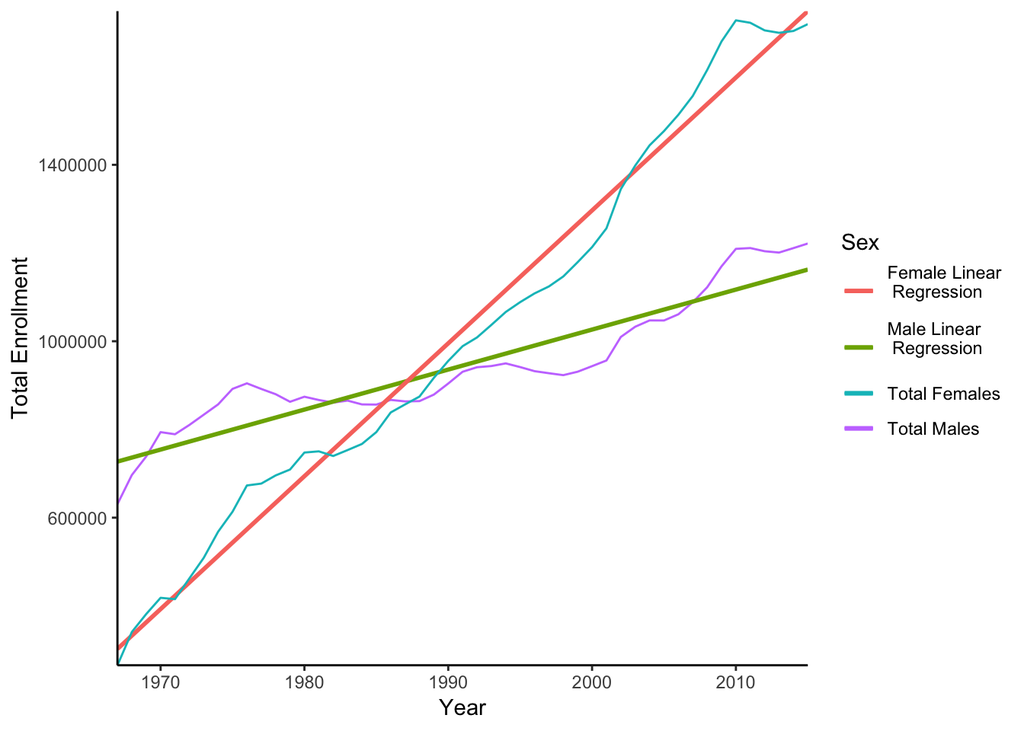

**Figure 1. Relationship between total female graduate enrolled students and year (1967-2015) and total male graduate enrolled students and year (1967-2015).** Year significantly predicts total female graduate enrollment (t(47) = 51.659, *p* < 0.001) with a strong positive correlation between the two variables (Pearson’s r = 0.99). Year also significantly predicts total male graduate enrollment (t(47) = 16.612, p < 0.001) with a strong positive correlation between the two variables (Pearson’s r = 0.92).

To determine whether there was an association between year and and number of enrolled male graduate students, a single variable linear regression model was run with ‘year’ being the independent variable and ‘total enrolled male graduate students’ being the dependent variable. The year significantly predicts total male graduate enrollment (t(47) = 16.612, p < 0.001) with a strong positive correlation between the two variables (Pearson’s r = 0.92), (Fig. 1). To determine whether there was an association between year and and number of enrolled female graduate students, another single variable linear regression model was run with ‘year’ being the independent variable and ‘total enrolled female graduate students’ being the dependent variable. In this case, year also significantly predicts total female graduate enrollment (t(47) = 51.659, p < 0.001) with a strong positive correlation between the two variables (Pearson’s r = 0.99), (Fig. 1).

#### Changes in Female PhD recipients in Four Fields in 1985, 2000, and 2015

The number of female PhD recipients in physical and earth sciences, engineering, education, and humanities and the arts increased from 1985 to 2015. The amount of increase in female PhD recipients was substantial in physical and earth sciences, engineering, and humanities and the arts, while the increase in education was rather nominal.

| Field of Study | 1985 | 2000 | 2015 |
| --- | --- | --- | --- |
| Physical Sciences/Earth Sciences | 569 | 1022 | 1988 |
| Engineering | 198 | 838 | 2301 |
| Education | 3491 | 4179 | 3502 |
| Humanities/Arts | 1392 | 2672 | 2832 |

The large increases in female PhD recipients in STEM fields can also potentially be explained in shifting societal notions of what is considered “so-called” male or female professions. In the 1980s, it was still a popular notion in American society that “female professions” did not usually include professions such as a scientist or an engineer. However, as these notions have shifted significantly over the past several decades the number of female PhD recipients in STEM have increased dramatically.

#### A Comparison of Male and Female PhD Recipients’ Salaries for Postdoctoral and Other Employment Positions in 2015

Median salaries for male and female doctorate recipients in 2015 were examined to determine if the salaries are significantly different based on sex. A paired non-parametric Wilcoxon Signed-Rank test was used to compare median salaries for males and females within the same field, currently in postdoctoral positions. A separate paired Wilcoxon Sign-Rank test examined median salary difference for male and female doctorate recipients within the same field and employed in positions outside of postdoctoral research. In addition, Cliff’s delta tests were carried out to quantify the effect size of these groups.

For male and female doctorate recipients who are currently working as postdoctoral researchers, median salary did not differ significantly (V = 19.5, *p* = 0.9, $\alpha$ = 0.05, Cliff’s delta = negligible). In the fifteen fields examined, only three fields exhibited median male salaries that were greater than salaries of females: mathematics and computer sciences, education, and other fields not related to science and engineering. Postdoctoral pay in education depicted the greatest disparity in salary in preference of males, with males making $5,000 more than female postdoctoral researchers.

In contrast to salaries of postdoctoral researchers, a significant difference in median salary was determined for male and female doctorate recipients currently employed in positions not related to postdoctoral research (V = 101, *p* < 0.01, $\alpha$ = 0.05). In addition, the effect size is small to moderate (Cliff’s Delta = 0.21). Twelve out of the fifteen fields analyzed exhibited higher median salaries for males than females. The largest difference in median salaries, in which males were making more than females, was in the mathematics and computer sciences field, with a salary difference of $15,000. This finding should be examined further in future research to analyze why salaries differ for male and female doctorate recipients employed outside of postdoctoral research even though these recipients are within the same field.

#### An Analysis of Faculty Salaries in United States Higher Education

*Table 2. Multivariate Linear Regression for Faculty Salaries in the US.* Results of the multivariate linear regression to examine faculty salaries in the US in comparison to sex, faculty rank, department type, and years since obtaining a PhD.

|  | *Dependent variable:* |
| --- | --- |
|  | Salary |
| Male (Sex) | 4,349.366 (3,875.393) |
| Assistant Professor (Rank) | -13,104.150*** (4,167.315) |
| Professor (Rank) | 32,928.400*** (3,544.403) |
| Years Since PhD | 61.011 (127.010) |
| Applied Department | 13,937.470*** (2,346.534) |
| Constant | 80,988.470*** (4,931.844) |
| Observations | 397 |
| R<sup>2</sup> | 0.447 |
| Adjusted R<sup>2</sup> | 0.440 |
| Residual Std. Error | 22,663.240 (df = 391) |
| F Statistic | 63.266*** (df = 5; 391) |
| *Note:* | p<0.1; p<0.05; p<0.01 |

Many characteristics of faculty members at American universities have the potential to affect their salaries. To examine the influence of faculty characteristics on salary, a multiple linear regression model was created. The characteristics of faculty members included in the model are sex, faculty position, field, and years since obtaining a doctorate degree. The model [salary = 80,988.47 + 4,349.37(Male) - 13,104.15(Assistant Professor) + 32,928.40(Professor) + 61.01(Years Since PhD) + 13,937.47(Applied Field); in US $] significantly predicts faculty salary (F(391) = 63.27, p < 0.001, R2 = 0.44).

According to this model, if all other variables are the same, then male professors make $4,349.37 more than female professors. In addition, this model indicates that faculty members with ranking as professors make $32,928.40 more than associate professors, if every other variable remains the same. Thus, professor rank seems to have more influence on faculty salary than the faculty member’s sex. Furthermore, it is observed that faculty members in applied fields earn $13,937.47 than faculty members in theoretical fields, if all other variables remain the same. In addition, it is interesting, but not surprising, to note that the model indicates that assistant professors make less money than associate professors, as assistant professor positions are lower than associate ones.

It is important to note that 44% of the variance in faculty salaries can be predicted by the model’s variables. The model created is a good fit in determining the influence of sex, faculty position, field, and years since obtaining a PhD on faculty salaries because these variables show a linear relationship with faculty salary. Future research can focus on further examining the relationships between these factors and faculty salaries. Additionally, future studies can apply this model to faculty members of universities in other countries.

### Conclusion

Data on female and male enrolled graduate students, PhD recipients, salary, rank, and discipline are essential to understanding the disparities and inequities that exist in academia. The graduate enrollment data provided by the U.S. Department of Education’s National Center for Education Statistics Higher Education General Information Survey should continue going forward so that solutions can be devised to address inequities between genders in academia. Information on doctoral recipients and their median salaries provided by the National Science Foundation’s National Center for Science and Engineering Statistics Survey of Earned Doctorates will be helpful in the larger gender pay disparity discussion in academia, as well as the entire economy. Survey data gathered by Fox J. and Weisberg, S. (2011) An R Companion to Applied Regression, Second Edition Sage on professor characteristics and associated salaries will be useful in illuminating disparities among salaries based on faculty characteristics. A more thorough assessment of the data that goes beyond a survey in the future will lead to more accurate data regarding these two variables. Continued and improved data collection by American institutions in the coming years on graduate student enrollment, PhD recipients, and faculty salaries will provide policy makers, activists, and career professionals with the tools necessary to decrease pay inequities and improve the equity of sexes and professional representation in the future.